# Predicting selling price with Python

## Cleaning, analysing, visualizing and modeling data using Linear Regression

*By Alexandre Kocev*

Horizon Boat company is building and selling private boats in Europe. Willing to launch a new motor boat, they are asking us to analyse the European boat market. As a Data Analyst, we gathered data including a list of boats with their characteristics and price. Our goal is to define the features which have the greatest impact on price, and build a model to predict the price using Linear Regression.

*The original data was created by Artem and collected from [here](https://www.kaggle.com/artemkorottchenko/large-boatyacht-pricing-dataset). It was then reorganized by myself for the purpose of this case study.*

## STEP 1 : Set up the workspace and read the data

Import required Python libraries

```python
import pandas as pd
import matplotlib.pylab as plt
from matplotlib import pyplot
import numpy as np
import seaborn as sns
```

```python
import warnings
warnings.simplefilter(action="ignore", category=FutureWarning)
```

Upload CSV files through Pandas dataframes.

```python
df = pd.read_csv('motor_boat_market.csv', index_col=False, delimiter = ',')
```

Inspect our new dataframe.

```python
# overview the first 5 rows of the dataframe
df.head(5)
```

|  | price | boat_type | year_built | length | width | depth | displacement | cabins_number | material | engine_performance | fuel_capacity | fuel_type |
| --- | --- | --- | --- | --- | --- | --- | --- | --- | --- | --- | --- | --- |
| 0 | EUR 3.930,- | Sport Boat | 2020 | 4.31 m | 1.64 m | NaN | 94 kg | NaN | Aluminium | 1 x 3 HP / 2.2 kW | NaN | Unleaded |
| 1 | NaN | Cabin Boat | 1994 | 4.75 m | 1.86 m | 0.30 m | NaN | NaN | GRP | 1 x 30 HP / 22 kW | NaN | Unleaded |
| 2 | CHF 8.155,- | Bowrider | 2020 | 4.45 m | 1.85 m | NaN | 300 kg | NaN | Thermoplastic | NaN | NaN | Unleaded |
| 3 | CHF 9.500,- | Pontoon Boat | 2020 | 4.80 m | 1.80 m | NaN | NaN | NaN | GRP | 1 x 8 HP / 5.9 kW | 12 l | Unleaded |
| 4 | CHF 9.265,- | Sport Boat | 2020 | 4.80 m | 1.90 m | NaN | 370 kg | NaN | GRP | NaN | NaN | Unleaded |

```python
# describe each column
df.describe(include = 'all')
```

|  | price | boat_type | year_built | length | width | depth | displacement | cabins_number | material | engine_performance | fuel_capacity | fuel_type |
| --- | --- | --- | --- | --- | --- | --- | --- | --- | --- | --- | --- | --- |
| count | 1349 | 1350 | 1350.000000 | 1349 | 1346 | 738 | 671 | 651.000000 | 1171 | 1234 | 886 | 1350 |
| unique | 1098 | 14 | NaN | 415 | 207 | 101 | 292 | NaN | 7 | 125 | 173 | 5 |
| top | EUR 49.900,- | Sport Boat | NaN | 8.10 m | 2.50 m | 0.80 m | 1 kg | NaN | GRP | 1 x 200 HP / 147 kW | 200 l | Unleaded |
| freq | 11 | 315 | NaN | 25 | 101 | 73 | 19 | NaN | 856 | 118 | 41 | 1079 |
| mean | NaN | NaN | 2018.633333 | NaN | NaN | NaN | NaN | 1.459293 | NaN | NaN | NaN | NaN |
| std | NaN | NaN | 4.703476 | NaN | NaN | NaN | NaN | 0.770286 | NaN | NaN | NaN | NaN |
| min | NaN | NaN | 1986.000000 | NaN | NaN | NaN | NaN | 1.000000 | NaN | NaN | NaN | NaN |
| 25% | NaN | NaN | 2019.000000 | NaN | NaN | NaN | NaN | 1.000000 | NaN | NaN | NaN | NaN |
| 50% | NaN | NaN | 2020.000000 | NaN | NaN | NaN | NaN | 1.000000 | NaN | NaN | NaN | NaN |
| 75% | NaN | NaN | 2020.000000 | NaN | NaN | NaN | NaN | 2.000000 | NaN | NaN | NaN | NaN |
| max | NaN | NaN | 2021.000000 | NaN | NaN | NaN | NaN | 10.000000 | NaN | NaN | NaN | NaN |

## STEP 2 : Clean the data

### (1) Identify missing values and data type

We use the '.isnull()' function to return Bolean values. True means the value is missing while False means the value is not missing.

```python
# check for missing values
missing_data = df.isnull()
for column in missing_data.columns.values.tolist():
    print (missing_data[column].value_counts())
    print('')
```

```
False    1349
True        1
Name: price, dtype: int64

False    1350
Name: boat_type, dtype: int64

False    1350
Name: year_built, dtype: int64

False    1349
True        1
Name: length, dtype: int64

False    1346
True        4
Name: width, dtype: int64

False    738
True     612
Name: depth, dtype: int64

True     679
False    671
Name: displacement, dtype: int64

True     699
False    651
Name: cabins_number, dtype: int64

False    1171
True      179
Name: material, dtype: int64

False    1234
True      116
Name: engine_performance, dtype: int64

False    886
True     464
Name: fuel_capacity, dtype: int64

False    1350
Name: fuel_type, dtype: int64
```

```python
# check for data type
df.dtypes
```

```
price                  object
boat_type              object
year_built              int64
length                 object
width                  object
depth                  object
displacement           object
cabins_number         float64
material               object
engine_performance     object
fuel_capacity          object
fuel_type              object
dtype: object
```

```python
### (2) Drop columns with not enough entries
```

```python
df = df.drop(['depth','displacement', 'fuel_capacity'], axis=1)
```

### (3) Drop rows with missing key entry

Our analysis will be based on the boat Price so we delete the whole row when Price is missing.

```python
# Drop rows with missing Price
df.dropna(subset=['price'], axis=0, inplace=True)

# reset the index as we dropped rows
df.reset_index(drop=True, inplace=True)
```

### (4) Handle missing values in string columns

We first check distinct entries in the column Material, the only string column where some entries are missing.

```python
df['material'].value_counts()
```

```
GRP              855
PVC              244
Aluminium         34
Steel             23
Thermoplastic      6
Carbon Fiber       4
Wood               4
Name: material, dtype: int64
```

We replace missing entries with 'GRP' (Glass Reinforced Plastic) material. Since it is the most frequent, boats with missing material entries have the most likely chance to be built in 'GRP'.

```python
df['material'].replace(np.nan, 'GRP', inplace=True)
```

### (5) Convert string columns to numerical columns

Before handling missing values in numerical columns, we need to make sure they are all floats or integers.

Let's start with Length and Width. We need to remove the 'm' character before converting to float.

```python
# remove the meter character in Length and Width
df['length'] = df['length'].str.replace('m','')
df['width'] = df['width'].str.replace('m','')

# convert to float
df['length'] = df['length'].astype(float)
df['width'] = df['width'].astype(float)
```

We continue with Engine Performance. An example of current entries is : '1 x 350 HP / 257 kW'. We decide to multiply the number of engines with power measured in kW. Horse power is mostly used to measure power from combustion engines. However, some engines are electric, so we decide to use kW instead.

```python
# split column Engine Performance into two new columns : Number of Engines and Engine Power
df[['engines_number', 'engine_power']] = df['engine_performance'].str.split(' ', 1, expand=True)

# split the new column Engine Power into two other columns : Horse Power and kW
df[['hp', 'kw']] = df['engine_power'].str.split('/', expand=True)

# drop columns Engine Performance, Engine Power and Horse Power
df = df.drop(['engine_performance', 'engine_power','hp'], axis=1)

# remove kW character from column kW to later be able to convert to float
df['kw'] = df['kw'].str.replace('kW','')

# convert columns Number of Engines and kW to float
df['engines_number'] = df['engines_number'].astype(float)
df['kw'] = df['kw'].astype(float)

# create a new column Total Power and multiply Number of Engines with kW
df['total_power'] = df['engines_number'] * df['kw']

# drop column kW (we keep Number of Engines and Total Power)
df = df.drop(['kw'], axis=1)
```

### (6) Handle missing values in numerical columns

We replace the missing values in Length, Width, Number of Engines and Total Power with their respective mean values.

```python
# calculate the mean value for each column
avg_length = df['length'].mean()
avg_width = df['width'].mean()
avg_engines_number = df['engines_number'].mean()
avg_total_power = df['total_power'].mean()

# replace missing values with the mean value
df['length'].fillna(avg_length, inplace=True)
df['width'].fillna(avg_width, inplace=True)
df['engines_number'].fillna(avg_engines_number, inplace=True)
df['total_power'].fillna(avg_total_power, inplace=True)
```

We assume that missing values in Number of Cabins probably means that there are no cabins in the boat. We replace missing values to zero.

```python
df['cabins_number'].fillna('0', inplace=True)

# convert to integer
df['cabins_number'] = df['cabins_number'].astype(int)
```

Now, we have a dataset with no missing values and all data in its proper format.

### (7) Data standardization

We standardize the currency. Price columns include different currencies so we standardize currencies to Euro.

```python
# split the column Price into two new columns : Currency and Amount
df[['currency', 'amount']] = df['price'].str.split(' ', 1, expand=True)

# discover distinct currency in the new column Currency
df['currency'].value_counts()
```

```
EUR    1055
CHF     250
DKK      22
£        21
USD       1
Name: currency, dtype: int64
```

```python
# we convert all currencies to Euro in column Currency using the today conversion rate
df['currency'] = df['currency'].str.replace('EUR', '1')
df['currency'] = df['currency'].str.replace('CHF', '0.92')
df['currency'] = df['currency'].str.replace('£', '1.16')
df['currency'] = df['currency'].str.replace('DKK', '0.13')
df['currency'] = df['currency'].str.replace('USD', '0.84')

# remove all non numeric characters in column Amount
df['amount'] = df['amount'].str.replace('\.|\,|\-','', regex=True)

# replace values in column Price with Currency multiplied with Amount. It gives us prices in Euro.
df['price'] = df['currency'].astype(float) * df['amount'].astype(float)

# drop columns Currency and Amount
df = df.drop(['currency', 'amount'], axis=1)
```

### (8) Data normalization

We normalize the dimensions for boats by transforming Length and Width into a similar range between zero and one. This will allow more accurate analysis if we look at correlations between those two variables.

```python
df['length_normalized'] = df['length']/df['length'].max()
df['width_normalized'] = df['width']/df['width'].max()
```

### (9) Data binning

Bins are used to split numerical variables into different categories. We put all entries in Total Power inside 4 bins : low, medium, high and super.

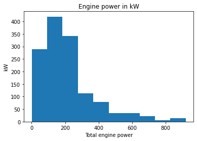

```python
# plot the distribution of current Total Power
import matplotlib as plt
from matplotlib import pyplot
pyplot.hist(df['total_power'])
pyplot.xlabel('Total engine power')
pyplot.ylabel('kW')
pyplot.title('Engine power in kW')
```

```python
# create bin array including minimum and maximum values and five delimiters
bins = np.linspace(min(df['total_power']), max(df['total_power']), 5)

# set group names
label_names = ['low', 'medium', 'high', 'super']

# create a new column and cut the array into four bins
df['total_power_binned'] = pd.cut(df['total_power'], bins, labels=label_names, include_lowest=True)
```

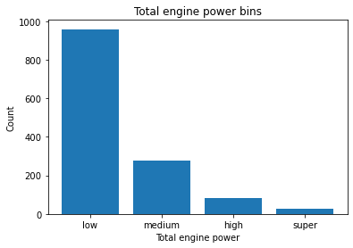

```python
# plot the distribution of the new built bins
import matplotlib as plt
from matplotlib import pyplot
pyplot.bar(label_names, df['total_power_binned'].value_counts())
pyplot.xlabel('Total engine power')
pyplot.ylabel('Count')
pyplot.title('Total engine power bins')
```

### (10) Narrow down observations

After handling all missing values, we narrow down our dataframe to only observations (rows) we need in order to build our prediction model.

We narrow down our dataframe to boats built after 2000 as we need recent observations to build an accurate prediction model.

```python
# keep observations for boats built only after 2000
df = df[df.year_built > 2000]
```

Horizon Boat builds boats using Unleaded, Diesel and Electricity as Fuel Type. We remove all other Fuel Types.

```python
# keep observations for boats using only Unleaded, Diesel, Electric as Fuel Type
horizon_fuel_type = ['Unleaded', 'Diesel', 'Electric']
df = df[df.fuel_type.str.contains('|'.join(horizon_fuel_type))]
```

Horizon Boat builds private boats with a limited number of cabins. We keep all observations for boats with no more than three cabins.

```python
# keep observations for boats having 3 or less cabins
df = df[df.cabins_number <= 3]
```

Horizon Boat builds certain types of boats so we only keep those types.

```python
# keep observations for only certain types of boat
horizon_boat_type = ['Sport Boat', 'Bowrider', 'Ponton Boat', 'Deck Boat', 'Center consol boat', 'Cabin Boat', 'Motor Yacht', 'Pilothouse', 'Hardtop', 'Flybridge']
df = df[df.boat_type.str.contains('|'.join(horizon_boat_type))]

# rename values with spaces
df['boat_type'] = df['boat_type'].replace('Cabin Boat', 'Cabinboat')
df['boat_type'] = df['boat_type'].replace('Deck Boat', 'Deckboat')
df['boat_type'] = df['boat_type'].replace('Motor Yacht', 'Motoryacht')
df['boat_type'] = df['boat_type'].replace('Sport Boat', 'Sportboat')
```

```python
# reset the index as we dropped rows
df.reset_index(drop=True, inplace=True)
```

Our dataframe is now wrangled. We have no more missing data, data is in its proper format, standardized, normalized and split into bins. We are ready for analysis.

## STEP 3 : Perform descriptive analysis and visualization

We wish to analyse and select the best variables to build our prediction model for boat Price. In other words, we check for correlation between Price and all other variables.

### (1) Determine correlation between Price and continuous quantitative variables

First, we describe continuous quantitative (numerical) variables by using the function '.describe()'. It shows us basic statistics including mean, standard deviation, minimum, maximum and interquartiles for each numerical column.

```python
df[['price', 'length', 'width', 'total_power']].describe()
```

|  | price | length | width | total_power |
| --- | --- | --- | --- | --- |
| count | 1.077000e+03 | 1077.000000 | 1077.000000 | 1077.000000 |
| mean | 1.567347e+05 | 8.171999 | 2.793028 | 227.856833 |
| std | 2.179223e+05 | 2.665190 | 0.669464 | 170.783342 |
| min | 3.930000e+03 | 1.150000 | 0.010000 | 0.700000 |
| 25% | 4.790000e+04 | 6.350000 | 2.440000 | 110.000000 |
| 50% | 7.787000e+04 | 7.490000 | 2.550000 | 184.000000 |
| 75% | 1.766150e+05 | 9.350000 | 3.000000 | 257.000000 |
| max | 2.285156e+06 | 23.200000 | 7.550000 | 920.000000 |

Then, we use scatter plots to visualize correlation between each continuous quantitative variable (as X axis) and Price (as Y axis).

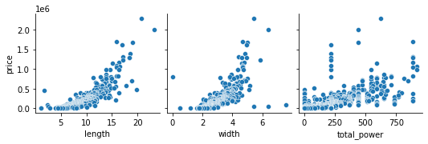

```python
import matplotlib.pylab as plt
sns.pairplot(df, x_vars=['length', 'width', 'total_power'], y_vars=['price'])
plt.show()
```

We visualize that Length and Width variables might be good predictors for Price. Let's confirm by using the function '.corr()' which shows us the Pearson coefficient (or correlation coefficient). It measures the linear dependence between two variables. 1 means perfect positive linear correlation, 0 means no linear correlation and -1 means perfect negative linear correlation.

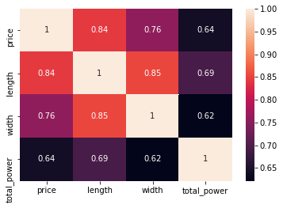

```python
# heatmap to better visualize Pearson coefficient
sns.heatmap(df[['price', 'length', 'width', 'total_power']].corr(), annot=True)
plt.show()
```

### (2) Determine correlation between Price and discrete quantitative variables

Our discrete quantitative variable is Number of Cabins. We use boxplot to visualize a possible correlation with Price.

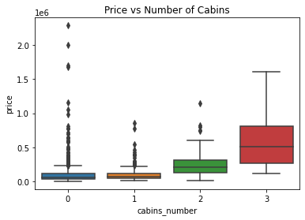

```python
# boxplot showing Price vs Number of Cabins
sns.boxplot(y='price', x='cabins_number', data=df).set(title='Price vs Number of Cabins')
plt.show()
```

Distribution of Price between Number of Cabins shows a positive correlation. More cabins means higher prices. Let's see if we have enough observations for each Number of Cabins.

```python
# show amount of observations for each category
df['cabins_number'].value_counts()
```

```
0    531
1    359
2    143
3     44
Name: cabins_number, dtype: int64
```

We visualize a positive correlation and count enough observations for each category. As a result, Number of Cabins appears as a good predictor for Price.

### (3) Determine correlation between Price and qualitative variables

First, we look at a summary of those variables using the function '.describe()'.

```python
df.describe(include=['object'])
```

|  | boat_type | material | fuel_type |
| --- | --- | --- | --- |
| count | 1077 | 1077 | 1077 |
| unique | 8 | 7 | 3 |
| top | Sportboat | GRP | Unleaded |
| freq | 309 | 876 | 854 |

Let's analyse if Price is correlated with any qualitative (text) variables using boxplots.

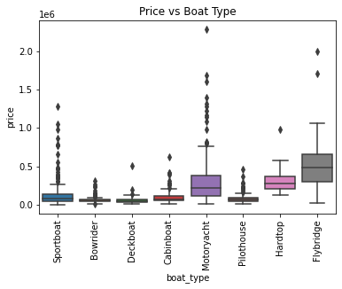

```python
# boxplot showing Price vs Boat Type
sns.boxplot(y='price', x='boat_type', data=df).set(title='Price vs Boat Type')
# rotate labels in x axis
plt.xticks(rotation = 90)
plt.show()
```

It is visually difficult to see correlation between Price and Boat Type using boxplots. Let's continue our analysis by looking at the amount of observations for each category.

```python
df['boat_type'].value_counts()
```

```
Sportboat     309
Pilothouse    159
Motoryacht    148
Bowrider      144
Cabinboat     126
Deckboat       80
Hardtop        73
Flybridge      38
Name: boat_type, dtype: int64
```

We have enough observations for each category. We continue our analysis with a statistical method : ANOVA.

ANOVA or Analysis of Variance is used to determine differences between the means of several grouped variables. It returns two parameters :

- F-test score calculates the difference between the mean for each group. Larger difference between means suggest better correlation.
- P-value shows how statistically significant is our correlation between variables.

```python
from scipy import stats
# group Price by Boat Type
grouped_boat_type = df[['boat_type', 'price']].groupby(['boat_type'])

# extract individual Boat Types
sportboat = grouped_boat_type.get_group('Sportboat')['price']
pilothouse = grouped_boat_type.get_group('Pilothouse')['price']
motoryacht = grouped_boat_type.get_group('Motoryacht')['price']
bowrider = grouped_boat_type.get_group('Bowrider')['price']
cabinboat = grouped_boat_type.get_group('Cabinboat')['price']
deckboat = grouped_boat_type.get_group('Deckboat')['price']
hardtop = grouped_boat_type.get_group('Hardtop')['price']
flybridge = grouped_boat_type.get_group('Flybridge')['price']

# perform the ANOVA
f_val, p_val = stats.f_oneway(sportboat, pilothouse, motoryacht, bowrider, cabinboat, deckboat, hardtop, flybridge)

print('The F-score is : ', f_val)
print('The P-value is : ', p_val)
```

```
The F-score is :  62.304593979649006
The P-value is :  3.442438883997577e-75
```

The F-score is large enough to show strong correlation between groups. P-value is below 0.001 which means that the correlation between Price and Boat Type is statistically significant. After all these analyses, we decide to keep Boat Type as a predictor for Price.

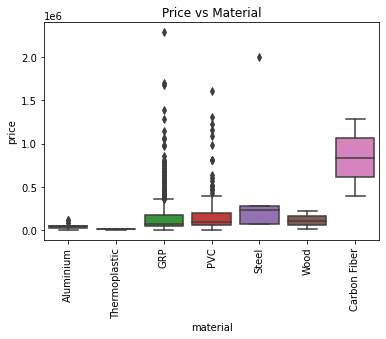

```python
# boxplot showing Price vs Material
sns.boxplot(y='price', x='material', data=df).set(title='Price vs Material')
# rotate labels in x axis
plt.xticks(rotation = 90)
plt.show()
```

```python
df['material'].value_counts()
```

```
GRP              876
PVC              172
Aluminium         16
Steel              5
Wood               3
Thermoplastic      3
Carbon Fiber       2
Name: material, dtype: int64
```

Boxes overlap and some categories have too few observations. We do not keep Material as a predictor for Price.

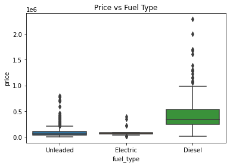

```python
# boxplot showing Price vs Fuel Type
sns.boxplot(y='price', x='fuel_type', data=df).set(title='Price vs Fuel Type')
plt.show()
```

We visualize a correlation between Price and Fuel Type. Observations with Unleaded and Electric have lower Price while observations with Diesel have higher Price. Let's see the amount of observations for each category.

```python
df['fuel_type'].value_counts()
```

```
Unleaded    854
Diesel      198
Electric     25
Name: fuel_type, dtype: int64
```

We see enough observations for each Fuel Type. As a result, Fuel Type is a good predictor for Price.

To conclude STEP 3, here are the predictors we selected for our prediction model :

Continuous quantitative variable :

- Length
- Width

Categorical variables :

- Number of Cabins (discrete quantitative variable)
- Boat Type (qualitative variable)
- Fuel Type (qualitative variable)

## STEP 4 : Predict Price with Multiple Linear Regression

MLR, or Multiple Linear Regression is used to calculate a dependant variable (i.e. Price) based on multiple independent variables (i.e. predictors selected in STEP 3 : Length, Width, Number of Cabins, Boat Type, Fuel Type).

### (1) Pre process data with Dummy variables

Our categorical variables (i.e. Number of Cabins, Boat Type, Fuel Type) need to be transformed to Dummy variables in order to perform MLR. Dummy variables -or indicator variables- are used to convert each distinct attribute in categorical variables into zero or one. Zero represents the absence of the attribute and one represents the presence.

Doing so allows us to model our linear relationship.

```python
# transform Number of Cabins to qualitative variables so we can later allocate dummy variables
df['cabins_number'] = df['cabins_number'].replace(0, 'zero')
df['cabins_number'] = df['cabins_number'].replace(1, 'one')
df['cabins_number'] = df['cabins_number'].replace(2, 'two')
df['cabins_number'] = df['cabins_number'].replace(3, 'three')

# assign variable X for all independent variables (predictors)
X = df[['length', 'width', 'cabins_number', 'boat_type', 'fuel_type']]

# allocate dummy variables to all categorical variables in X
X = pd.get_dummies(data=X)

# have a look on our new dataframe X
X.head()
```

|  | length | width | cabins_number_one | cabins_number_three | cabins_number_two | cabins_number_zero | boat_type_Bowrider | boat_type_Cabinboat | boat_type_Deckboat | boat_type_Flybridge | boat_type_Hardtop | boat_type_Motoryacht | boat_type_Pilothouse | boat_type_Sportboat | fuel_type_Diesel | fuel_type_Electric | fuel_type_Unleaded |
| --- | --- | --- | --- | --- | --- | --- | --- | --- | --- | --- | --- | --- | --- | --- | --- | --- | --- |
| 0 | 4.31 | 1.64 | 0 | 0 | 0 | 1 | 0 | 0 | 0 | 0 | 0 | 0 | 0 | 1 | 0 | 0 | 1 |
| 1 | 4.45 | 1.85 | 0 | 0 | 0 | 1 | 1 | 0 | 0 | 0 | 0 | 0 | 0 | 0 | 0 | 0 | 1 |
| 2 | 4.80 | 1.90 | 0 | 0 | 0 | 1 | 0 | 0 | 0 | 0 | 0 | 0 | 0 | 1 | 0 | 0 | 1 |
| 3 | 5.10 | 2.10 | 0 | 0 | 0 | 1 | 0 | 0 | 0 | 0 | 0 | 0 | 0 | 1 | 0 | 0 | 1 |
| 4 | 5.00 | 2.00 | 0 | 0 | 0 | 1 | 0 | 0 | 1 | 0 | 0 | 0 | 0 | 0 | 0 | 0 | 1 |

```python
# assign variable Y for the dependent variable : Price
Y = df['price']
```

### (2) Train our Linear Regression

Our data is assigned between Y (i.e. dependent variable : Price) and X (i.e. independent variables or predictors : Length, Width, Number of Cabins, Boat Type, Fuel Type). We now split X and Y between train and test sets. We choose to assign 90% of the data to the train set and 10% to the test set. The train set allows us to build the model while the test set allows us to measure the accuracy of the model.

```python
from sklearn.model_selection import train_test_split

# split Y and X between a train and test set. PS : we use random_state to have identical results for each run.
X_train, X_test, Y_train, Y_test = train_test_split(X, Y, test_size=0.1, random_state=11)

from sklearn.linear_model import LinearRegression

# create an object for the linear regression
model = LinearRegression()

# fit X_train and Y_train to the linear regression
model.fit(X_train,Y_train)
```

```
LinearRegression()
```

### (3) Test our Linear Regression

Let's look at how accurate our model is using the test set. We start with visualizations and then use statistical measurements.

[figure not shown]

```python
# assign a variable to show predictions performed by the model
predictions = model.predict(X_test)

# visualize with a scatter plot
sns.regplot(Y_test, predictions).set(title='Distribution of Actual vs Predicted Prices')
plt.show()
```

Let's make a second visualization using a distribution plot.

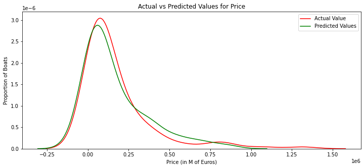

```python
# dimensions of the distribution plot
plt.figure(figsize=(12, 5))

# draw the curve of both variables showing the predicted (green) and the actual (red) price
ax1 = sns.distplot(Y_test, hist=False, color="r", label="Actual Value")
ax2 = sns.distplot(predictions, hist=False, color="g", label="Predicted Values")

plt.title('Actual vs Predicted Values for Price')
plt.xlabel('Price (in M of Euros)')
plt.ylabel('Proportion of Boats')

plt.legend()
plt.show()
```

Our model shows relatively good predictions. Let's finalize our analysis for model accuracy by calculating R^2.

```python
print('R^2 or accuracy of our model : ', model.score(X_test, Y_test))
```

```
R^2 or accuracy of our model :  0.8371929020388763
```

Our model is accurate up to 84% of the time.

### (4) Write down our Linear Regression

Our model shows good accuracy, so we can now use it for making Price predictions.

The equation of Multiple Linear Regression is given as :  
Y = a + b1.X1 + b2.X2 + bn.Xn

Where 'Y' is the dependant variable (i.e. Price) and each 'X' represents one predictor (i.e. Length, Width, Number of Cabins, Boat Type, Fuel Type).  
'a' is the intercept which is the theoretical value of the dependent variable when predictors are set to zero.  
'b' is the coefficient assigned for each predictor.

```python
# look at the intercept
print('The intercept is : ', model.intercept_)
```

```
The intercept is :  -411008.14585472393
```

```python
# show predictors and their respective coefficient
coeff_parameter = pd.DataFrame(model.coef_,X.columns,columns=['Coefficient'])
coeff_parameter
```

|  | Coefficient |
| --- | --- |
| length | 57171.737385 |
| width | 48458.200513 |
| cabins_number_one | -18555.511047 |
| cabins_number_three | 72152.454983 |
| cabins_number_two | -57782.894968 |
| cabins_number_zero | 4185.951031 |
| boat_type_Bowrider | 40006.719840 |
| boat_type_Cabinboat | 8116.189347 |
| boat_type_Deckboat | 1474.854339 |
| boat_type_Flybridge | -34870.312114 |
| boat_type_Hardtop | -48317.606542 |
| boat_type_Motoryacht | 4716.707473 |
| boat_type_Pilothouse | -4255.442240 |
| boat_type_Sportboat | 33128.889898 |
| fuel_type_Diesel | 6709.279568 |
| fuel_type_Electric | 44261.781745 |
| fuel_type_Unleaded | -50971.061313 |

We now have all inputs to write the function to predict boat Price.

### (5) Predict with our Linear Regression

Let's assume Horizon Boat is planning to build a new boat and wish to know the selling price based on the actual boat market. The engineer and marketing team agreed on those features : Yacht with three cabins, 16.5 meters long, 6.2 meters wide and using a diesel engine.

```python
predicted_price = model.predict([[16.5, 6.2, 0, 1, 0, 0, 0, 0, 0, 0, 0, 1, 0, 0, 1, 0, 0]])
print('According to our model, the predicted price is :', predicted_price)
```

```
According to our model, the predicted price is : [916344.80621172]
```

According to our model, the prediction of the selling price of the new boat is 916,344 Euros.

### (6) Plan for further analysis

We have our model to use for predicting boat prices. However its accuracy can be improved. As a data analyst, we should keep our work updated by checking for more available data, incorporating more independent variables (while avoiding overfitting the model), using Polynomial or Ridge Regression, etc.

Thank you for reading my case study. Feel free to contact me if you have any remarks or questions at : alexandre.kocev@gmail.com

Have a lovely day ahead.